# 04.02.01.00.RelatividadEspecial.TransformacionesLorentzEinstein.Propiedades

Indice | Previo: RelatividadEspecial.TransformacionesLorentzEinstein | Siguiente: RelatividadEspecial.TransformacionesLorentzEinstein.Consecuencias

## 4.7. Propiedades de las TLE

Las transformaciones de Lorentz-Einstein juegan un papel central en el estudio de todas las propiedades del espacio-tiempo que se derivan de los postulados de la relatividad.

**Postulado: Postulado de relatividad espacial.** Todas las leyes de la física son covariantes bajo las transformaciones de Lorentz-Einstein.

### 4.7.1. Unidades luz

La característica más notable de las TLE es que combinan espacio y tiempo en un mismo conjunto de ecuaciones de transformación. Este hecho de entrada rompe con el tiempo absoluto de la física newtoniana.

Al hacerlo sin embargo crea el problema de que en una misma ecuación (y en otros contextos en la teoría) tengamos cantidades muy diferentes desde el punto de vista físico y dimensional como lo son el tiempo y el espacio.

Una manera de subsanar este inconveniente es midiendo una de estas cantidades con unidades análogas a la otra. En Astronomía estamos por ejemplo acostumbrado a medir las distancias con unidades de tiempo cuando decimos que la estrella más cercana esta a 4.2 años-luz (al) de distancia. Dada una cantidad $x$, medida en unidades de longitud, la cantidad equivalente medida en unidades de tiempo será:

$$ x_L=\frac{x}{c} $$

donde $[x_L]=$sl (segundos luz).

Menos frecuente es usar unidades de distancia para referirse al tiempo. De manera análoga a como medimos 1 segundo-luz (sl), podemos definir 1 metro-luz como el tiempo que le toma a la luz recorrer un metro. El tiempo $t_L$ en metros luz se calcula como:

$$ t_L=ct $$

En unidades luz, la velocidad (la rapidez o cualquier componente) es:

$$ v_L=\frac{\mathrm{d}x_L}{\mathrm{d}t}=\frac{1}{c}\frac{\mathrm{d}x}{\mathrm{d}t}=\frac{v}{c} $$

### 4.7.2. La TLE como una rotación hiperbólica

Las transformaciones de Lorentz en términos de cantidades escritas en unidades luz serán:

\begin{eqnarray} \nonumber t' & = & \gamma\left(t - u_L x_L \right)\\ \nonumber x'_L & = & \gamma\left(- u_L t + x_L\right) \end{eqnarray}

o bien:

\begin{eqnarray} \nonumber t'_L & = & \gamma\left(t_L - u_L x \right)\\ \nonumber x' & = & \gamma\left(- u_L t_L + x\right) \end{eqnarray}

En ambos casos podemos si definimos $u_L\equiv u/c$, que no es otra cosa que la rapidez medida en unidades luz, las TLE se pueden escribir de forma:

$$ \left( \begin{array}{c} t'\\ x'_L \end{array} \right) = \Lambda(u_L) \left( \begin{array}{c} t\\ x_L \end{array} \right) $$

donde

$$ \Lambda(u_L)\equiv\left( \begin{array}{cc} \gamma & -\gamma u_L\\ -\gamma u_L & \gamma \end{array} \right) $$

y $\gamma=(1-u_L^2)^{-1/2}$.

Esta matriz tiene dos propiedades interesantes:

1. $\det \Lambda=1$
2. $\Lambda(u_L)^{-1}=\Lambda(-u_L)$

Que son las mismas propiedades de las matrices de rotación:

$$ R(\theta)\equiv\left( \begin{array}{cc} \cos\theta & -\sin\theta\\ \sin\theta & \cos\theta \end{array} \right) $$

$$ R_h(\phi)\equiv\left( \begin{array}{cc} \cosh\phi & \sinh\phi\\ \sinh\phi & \cosh\phi \end{array} \right) $$

donde $\phi$ más que un ángulo, es un parámetro de rotación.

Si hacemos la identificación:

es fácil probar que

$$ \sin\phi=\gamma u_L $$

**Definición 6.4. Vector posición en el espacio-tiempo.** Al vector:

> $$ x^\mu= \left( \begin{array}{c} t\\ x_L\\ y_L\\ z_L\\ \end{array} \right) $$

> lo llamaremos el vector posición en el espacio-tiempo.

### 4.7.3. Las TLE y la notación de Einstein

Otra manera de escribir la TLE aprovechando que puede expresarse matricialmente es:

$$ x'_\mu=\sum_\nu \Lambda_{\mu\nu} x_\nu $$

donde $\mu,\nu: 0 (t), 1(x), 2 (y), 3 (z)$ y $\Lambda_{\mu\nu}$ son las componentes de la matriz de rotación.

Con lo común que será manipular expresiones como estas, estar escribiendo sumatorias por todas partes se hace muy incómodo. Para evitarlo Einstein invento una notación que se vale de una importante propiedad matemática.

**Definición 6.5. componentes covariantes y contravariantes de un vector.** Dado un espacio coordenado de 4 dimensiones, y un conjunto de 4 vectores $\vec e_0$, $\vec e_1$, $\vec e_2$, $\vec e_3$ no paralelos entre sí (que llamaremos base). Cualquier vector $\vec v$ en el espacio tiene asociados 4 números que llamamos sus componentes, definidos de la siguiente maneral:

> 1. **Componentes contravariantes**, $\vec v:(v^0,v^1,v^2,v^3)$, que son tales que: $$ \vec v=v^0 \vec e_0+v^1 \vec e_1+v^2 \vec e_2+v^3 \vec e_3 $$ Los llamamos *contravariantes* porque si un cambio de escala modifica las longitudes de $\vec e_\mu$ por un factor $k$, las componentes $v^\mu$ se modificaran por un factor $1/k$ (*contrario* a los vectores de base).
> 2. **Componentes covariantes**, $\vec v:(v_0,v_1,v_2,v_3)$, que son tales que: $$ v_0=\vec v\cdot\vec e_0,\;v_1=\vec v\cdot\vec e_1,\;v_2=\vec v\cdot\vec e_2,\;v_3=\vec v\cdot\vec e_3 $$ Los llamamos *covariantes* porque si un cambio de escala modifica las longitudes de $\vec e_\mu$ por un factor $k$, las componentes $v^\mu$ se modificaran por un factor $k$ (*contrario* a los vectores de base).

> Las componentes contravariantes y covariantes de un vector coinciden si: 1) El producto punto es el definido en el espacio euclidiano y 2) si los vectores de la base son ortogonales$^1$.

Nótese que en términos compactos cualquier vector se puede escribir en términos de sus componentes contravariantes como:

$$ \vec v=\sum_\mu v^\mu \vec e_\mu $$

Para abreviar la expresión anterior usaremos en lo sucesivo la convención de que cuándo en una suma, los índices se repiten (normalmente en posiciones covariantes y contravariantes) entonces, la sumatoria correspondiente al índice se puede eliminar. Al índice lo llamamos también un *índice mudo* y su nombre puede cambiarse a voluntad. Así:

$$ \vec v=\sum_\mu v^\mu \vec e_\mu=v^\mu \vec e_\mu=v^\nu \vec e_\nu $$

En lo sucesivo y en un espíritu similar, usaremos la expresion $v^\mu$ para referirnos al vector $\vec v$ mismo.

En términos de la notación de Einstein y de las componentes contravariantes del vector posición en el espacio tiempo $x^\mu$ las TLE se pueden escribir como:

$$ x^{\mu'}=\Lambda^{\mu'}_\nu x^{\nu} $$

aquí $\nu$ es un índice mudo y $\mu'$ es el índice de la ecuación.

Las componentes explícitas de la matriz $\Lambda^{\mu'}_\nu$ son, cuando la velocidad va en la dirección del eje $x$:

$$ \begin{array}{c} \Lambda^{0'}_0=\Lambda^{1'}_1=\gamma\\ \Lambda^{2'}_2=\Lambda^{3'}_3=1\\ \Lambda^{0'}_1=\Lambda^{1'}_0=-u_L\gamma\\ \end{array} $$

### 4.7.4. Las TLE generales

Las transformaciones deducidas hasta aquí asumían que la velocidad relativa entre los sistemas de referencia inerciales iba en la dirección del eje x. Aunque siempre es posible hacer esa elección, puede ser también común que otras direcciones sean más importantes para definir nuestro sistema de coordenadas. Por tal razón tiene mucho interés escribir las TLE cuando $\vec u$ es arbitraria.

**Proposición: Transformaciones de Lorentz-Einstein vectoriales.** Si dos sistemas de referencia $O$ y $O'$ tienen velocidad relativa $\vec u$, sus medidas de espacio y tiempo se relacionan a través de:

\begin{eqnarray} t' & = & \gamma\left(t-\vec{u}_L\cdot \vec{r}_L\right) \\ \vec{r}'_L & = & \vec{r}_L+\left(\frac{\gamma-1}{u_L^2} \vec{u}_L\cdot \vec{r}_L - \gamma t\right)\vec u_L \end{eqnarray}

Esta transformación general puede entenderse si se escribe $\vec r=r_\parallel \hat u+r_\bot \hat v$, donde $\hat v\cdot \hat u = 0$. Remplazando, la transformación queda:

\begin{eqnarray} \nonumber t' & = & \gamma\left(t-u_L r_\parallel\right) \\ \nonumber r'_\parallel & = & r_\parallel+\left(\frac{\gamma-1}{u_L^2} u_L r_\parallel - \gamma t\right)u_L \\ \nonumber & = & \gamma(-u_L t + r_\parallel)\\ \nonumber r'_\bot & = & r_\bot \\ \end{eqnarray}

que es exactamente la TLE original.

Es posible probar que las componentes de la matriz de rotación del TLE en el caso general son:

$$ \Lambda^{0'}_0=\gamma\\ \Lambda^{0'}_i=\Lambda^{i'}_0=-\gamma u_L^i\\ \Lambda^{i'}_j=\delta_{ij}+(\gamma-1)u_L^i u_L^j / u_L^2\\ $$

### 4.7.5. El valor del factor de Lorentz-Einstein

Las TLE dependen del valor de $u_L$ y del factor de Lorentz $\gamma$. Es importante familiarizarse con el valor de estas cantidades.

La primera propiedad importante es que $u_L<1$ y por lo tanto $\gamma>1$. Ahora bien para velocidades comunes (la velocidad de un vehículo, un avión, un planeta, incluso una estrella o una galaxia), $u_L\ll 1$. Por la misma razón entonces el factor se puede expandir usando el teorema del binomio:

$$ \gamma=\frac{1}{\sqrt{1-u_L^2}}=1+\frac{u_L^2}{2}+{\cal O}(u_L^3) $$

o lo que es lo mismo:

$$ \gamma-1=\frac{u_L^2}{2}+{\cal O}(u_L^3) $$

A menudo es más fácil calcular $\gamma-1$ que $\gamma$ mismo.

Un gráfico del factor de Lorentz como función de la fracción $u_L$ se muestra en la figura abajo.

```python
%matplotlib inline
```

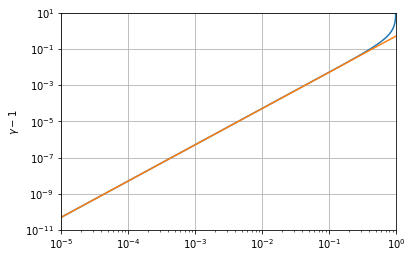

```python
from numpy import log10,sqrt,logspace
us=logspace(log10(1e-5),log10(0.9999),1000)
gammas=1/sqrt(1-us**2)-1
gamma_approx=us**2/2

import matplotlib.pyplot as plt
fig=plt.figure()
ax=fig.gca()

ax.plot(us,gammas,label='Exacto')
ax.plot(us,gamma_approx,label='Aprox. binomial')

ax.set_xscale("log")
ax.set_yscale("log")
ax.set_xlim((1e-5,1e0))
ax.set_ylim((1e-11,1e1))

ax.set_label(r"$u/c$")
ax.set_ylabel(r"$\gamma-1$")
ax.grid()
```

**Figura 4.5.**

### 4.7.6. Mapas de la TLE

¿Cómo se ven gráficamente las TLE?. Para mostrar cómo se ven la TLE podemos definir esta rutina general que permite el cálculo de $x^{\mu'}$ dados los valores de $x^{\mu}$:

```python
def Lambda_TLE(u):
    from numpy import zeros
    Lambda=zeros((4,4))

    #Factor de Lorentz
    umag=(u[0]**2+u[1]**2+u[2]**2)**0.5
    gamma=(1-umag**2)**(-0.5)

    #Lambda
    Lambda[0,0]=gamma
    Lambda[0,1:]=-u*gamma
    Lambda[1:,0]=-u*gamma
    for i in range(1,4):
        for j in range(1,4):
            dij=0
            if i==j:dij=1
            Lambda[i,j]=dij+(gamma-1)*u[i-1]*u[j-1]/umag**2
    return Lambda
```

Construyamos por ejemplo una transformación sencilla escogiendo la velocidad en la dirección de $x$:

```python
from numpy import array
u=array([0.2,0.0,0.0])
Lambda=Lambda_TLE(-u)
```

[output not shown]

Una manera de visualizar las transformaciones de Lorentz-Einstein es ver qué valor de $t'$, $x'$ toman eventos con valor de $t$ o $x$ constantes:

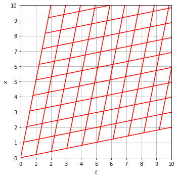

```python
#Escoge valores de x:
from numpy import linspace
rmax=10
xs=linspace(0,rmax,rmax+1,endpoint=True)
ts=linspace(0,rmax,rmax+1,endpoint=True)

#Calcula valores de t' y x' usando la matriz:
from numpy import zeros_like
tps=zeros_like(xs)
xps=zeros_like(xs)

from numpy import matmul

import matplotlib.pyplot as plt
fig=plt.figure(figsize=(5,5))
ax=fig.gca()

for t in xs:
    for i,x in enumerate(xs):
        tps[i],xps[i],yp,zp=matmul(Lambda,[t,x,0,0])
    ax.plot(tps,xps,'r-')

for x in xs:
    for i,t in enumerate(ts):
        tps[i],xps[i],yp,zp=matmul(Lambda,[t,x,0,0])
    ax.plot(tps,xps,'r-')

#Decoración
ax.set_xticks(xs)
ax.set_yticks(xs)
ax.set_xlabel("$t$")
ax.set_ylabel("$x$")
ax.set_xlim((0,rmax))
ax.set_ylim((0,rmax))
ax.grid()
fig.tight_layout()
```

**Figura 4.6.**

**NOTAS AL PIE:**

1. Un video con una explicación de la diferencia entre componentes contravariantes y covariantes puede encontrarse aquí: https://www.youtube.com/watch?v=CliW7kSxxWU

Indice | Previo: RelatividadEspecial.TransformacionesLorentzEinstein | Siguiente: RelatividadEspecial.TransformacionesLorentzEinstein.Consecuencias